# 5주차 분석 과정과 한계 — 프롬프트에서 검토까지

본문 바로가기

WEEK 05 / ANALYSIS RECORD

의생명과학프로그래밍 · 문서 작성 2026.10.06 · 분석 기록 2026.10.04

읽기 순서

프롬프트의 계획과 실제 실행 기록을 구분해 읽습니다.  
이 문서는 저장된 결과를 설명하는 후속 자료입니다.

분석 과정 · 발견한 문제 · 남은 의문

# 논문 한 편을 *어떻게 분석하고 검토했는가*

최종 판정: 부분 재현

치주질환·구강건강과 고혈압의 연관을 NHANES 2009–2018 자료로 재구성했습니다. 원문 수치를 따라 적는 대신, **질문 → 측정 → 코딩 → 표본 → 검정·모형 → 검토 → 해석**의 연결을 확인했습니다. 이 자료는 각 선택의 근거와 확인하지 못한 부분까지 함께 설명합니다.

**21,458**현재 기본 분석 표본논문 21,800명보다 342명 적음

**7 / 84**출판 OR 비교에서 허용오차 내 일치OR만의 0.005 판정 · 완전 재현 아님

**R2 · E2 · V1**현재 읽을 실행 결과기본 분석 · 보정된 확장 분석 · 과제 검증

대상 논문: Li et al., BMC Public Health (2023), PMID 37308938 · DOI 10.1186/s12889-023-16012-z  
원문: [The association of periodontal disease and oral health with hypertension, NHANES2009–2018](https://link.springer.com/article/10.1186/s12889-023-16012-z)

01

SCOPE

## 무엇을 재현하고, 무엇을 별도로 검증했나

논문의 연관 분석과 강의의 통계 원리 확인은 자료·추정 대상이 다르므로 두 갈래로 진행했습니다.

### 논문 재구성: R 경로

30세 이상 참가자의 자가보고 치주질환·구강상태와 고혈압의 연관을 확인합니다. 비가중 분할표, 가중 기술통계, 설계 기반 검정, 보정 로지스틱 모형을 계산합니다.

**출력** · Table 1–3, 흡연·연령 하위집단, 보충표 후보, OR·CI·추세·상호작용, 출판 수치와 차이.

### 과제 검증: V 경로

독립 이항 표집에서 Fisher의 실제 기각확률을 확인하고, 흔한 결과의 crude OR·PR 차이를 비교합니다. McNemar는 짝지은 가상 예제에서만 계산합니다.

**출력** · 정확 열거, 조건당 10,000회 MC, 오류율·검정력 곡선, OR/PR 곡선, 강의 예제.

**여기서의 “재현”은 저자의 코드를 복제했다는 뜻이 아닙니다.**

공개된 정의·각주와 공식 코드북으로 실행 가능한 후보를 만들었습니다. 저자의 제외·결측·흡연·가중치 설정 일부는 식별되지 않았고, 최종 수치도 모두 일치하지 않습니다.

연구 질문과 자료 구조 ↗분석 범위 ↗필수 산출물 추적 ↗

02

PROMPT → EVIDENCE

## 프롬프트의 각 지시가 실제로 어디에 남았나

원본 v2.0의 절 번호를 그대로 사용해 지시·실행·확인할 파일을 연결했습니다. 절 번호는 실행 시간순을 뜻하지 않습니다.

전체 실행 프롬프트 v2.0 원본 ↗5주차 일관성 보강 규칙 ↗

| 원본 프롬프트 | 요구한 행동 | 이번에 수행한 행동 | 근거 |
| --- | --- | --- | --- |
| [1] 시작 점검과 프로젝트 계약 | 논문·과제·범위·환경을 먼저 고정한다. | 지정 PMID를 확인하고, NHANES 공개 자료·R 분석·uv 보조·필수 산출물을 project.json에 등록했다. | 프로젝트 계약 ↗환경 기록 ↗ |
| [2] 추론 흐름을 먼저 설명 | 원자료 → 코딩 → 선정 → 요약 → 모형 → 해석을 concept/paper 쌍으로 만든다. | 7단계 이론·논문 노트를 만들고, 자가보고 OHQ·복합표본·보정 OR의 의미를 구분했다. | 연구 질문 ↗단계 등록부 ↗ |
| [3] 의문을 분석 작업으로 전환 | 저자 설정 조사(R)와 통계적 타당성 검토(V)를 구분한다. | ISSUE-01~12를 기록하고 R2/E1/E2 재구성과 V1 과제 검증을 분리했다. 원문 수치의 근접도와 방법의 타당성을 같은 판정으로 읽지 않는다. | 작업 계약 ↗요구사항 연결 ↗ |
| [4] 역할과 독립성 | 조정·논문·계획·환경·구현·검토 역할을 나누고 정확한 결과를 검토한다. | 별도 인스턴스에서 자료·모형·검증을 감사했다. 같은 원자료를 검토한 것이며 새 외부 표본 검증은 아니다. 출판 결과 노출로 비맹검이었다. | E2 수치 검토 ↗E2 자료 검토 ↗ |
| [5] 작업 계약·소통·메모리 | 계획·가정·허용 입력·노출 이력·판정 기준과 변경 사유를 기록한다. | plan과 task packet, decisions, review에 근거를 남겼다. OR/CI 허용오차 0.005·정수 n 오차 0을 정했다. 일부 과거 절대경로는 이동 전 위치를 보존한다. | 결정 기록 ↗최종 계획 ↗ |
| [6] 변경·실패·재개 | 실패를 보존하고 상류 정의가 바뀌면 영향을 받는 하류를 갱신한다. | R1 헤더 오류를 새 R2에서 수정했다. E1 이후 J 검사법 차이를 확인하고 plan1.5를 검토한 뒤 E2를 실행했다. M1/M2는 재사용하고 M3 등은 재계산했다. | R1 실패 기록 ↗결과 의존 관계 ↗ |
| [7] 파일 구조와 소유권 | tasks는 작업·인계, runs는 계산, memory는 조정, assets는 검토된 그림 사본으로 둔다. | 원자료·실행을 덮어쓰지 않고 run별 표·그림·로그를 보존했다. 학습 문서 이미지 10개는 원본 그림과 해시를 대조했다. | 실행·폴더 안내 ↗이미지 해시 ↗ |
| [8] 기존 학습 문서에 통합 | 초기 설명과 의문을 보존하고 구현·비교·검토·갱신 해석을 해당 단계에 붙인다. | 01~07-paper에 결과를 반영하고 문서 검토를 받았다. 이 HTML은 2026-10-06 사용자 요청에 따른 후속 설명 자료이며 당시 분석을 새로 실행한 결과가 아니다. | 통합된 해석 ↗학습 문서 검토 ↗ |
| [9] 완료 판정 | 필수 항목의 구현·검토·문서 연결과 정확 재현 여부를 별도로 판정한다. | 정의 가능한 필수 범위는 완료했지만 최종 판정은 부분 재현이다. 선택 사항인 공통 완전사례 분석은 실행하지 않았고 저자 설정 질문은 남았다. | 완료 범위 추적 ↗완료·미실행 범위 ↗ |

**요구와 실제 수행이 달랐던 지점: 맹검**

5주차 규칙은 구현자에게 원문 수치 목표를 전달하지 않도록 요구했습니다. 그러나 원문 정의·각주를 읽을 때 결과 수치도 함께 노출됐고, 실제 기록은 “독립 인스턴스 검토, 비맹검”으로 정정했습니다. 기록은 출판값에 맞춘 최적화를 수행하지 않았다고 보고하지만, 수치 노출 가능성이 없었다고 주장하지 않습니다.

이 페이지는 프롬프트가 자동으로 실행·권한 차단을 보장했다는 설명이 아닙니다. 각 요구가 어떤 기록으로 확인되며 어디에서 미충족 또는 제한됐는지를 보여 줍니다.

노출 이력과 현재 계획 ↗맹검 정정과 계획1.5 ↗통합된 재현 한계 ↗

03

DATA → INFERENCE

## 한 사람의 자료가 표와 OR가 되는 과정

개인 응답을 변수로 바꾸고, 포함 여부를 정한 뒤, 복합표본 설계를 반영해 집단의 연관을 추정합니다. 개인 한 명의 p값이나 OR를 만드는 과정은 아닙니다.

공식 원자료·코드북*→*SEQN으로 병합*→*정의·분기·결측*→*선정·가중 설계*→*분할표·보정 모형*→*검토·학습 노트

1. STEP A / 논문과 측정 정의

### 과제 이미지와 논문의 측정을 대조했다

   지정 PMID·DOI를 확인하고 본문·표 각주·보충자료를 읽었습니다. “구강검진”이라는 과제 표현과 달리 이 논문은 자가보고 OHQ 설문을 사용합니다. 고혈압은 진단·현재 치료·측정 혈압의 후보 정의로 만들었습니다.

   논문 적용 01 ↗정의·출처 감사 ↗
2. STEP B / 원자료 → 분석 변수

### 응답 코드의 숫자를 그대로 수치로 취급하지 않았다

   OHQ의 Yes/No, 구강상태 범주, 7/9 같은 특별 코드와 문항 skip을 확인했습니다. 혈압은 유효 SBP/DBP 1~4회 평균 후보를 사용하고, 확실한 고혈압 양성 근거와 불명확한 음성을 구분했습니다. 흡연은 평생 100개비 이상 후보이며 현재흡연으로 바꿔 읽지 않습니다.

   논문 적용 02 ↗기본 코딩 코드 ↗
3. STEP C / 선정과 결측

### 제외 과정과 분모를 기록했다

   30세 이상, 유효 혈압, 구강 문항, 흡연, 고혈압 판정 순으로 분석집단을 구성했습니다. 범주 결측은 Missing 범주, 연속 결측은 주 분석 관측값의 중앙값과 결측 지시변수를 사용하는 후보입니다. 이 방법이 결측 편향을 없앴다고 판단하지 않았습니다.

   논문 적용 03 ↗기본 분석 정의 ↗

### 현재 후보의 선정 흐름

막대는 각 단계의 비가중 인원입니다. 제외 순서에 따른 후보 흐름이며 논문의 제외 코드 복원이 아닙니다.

전체 DEMO

**49,693**

30세 이상

**24,042**

유효 SBP·DBP

**22,163**

치주질환 응답

**21,515**

구강상태 응답

**21,488**

흡연 응답

**21,476**

고혈압 판정

**21,458**

양의 MEC 가중·설계

**21,458**

전체 흐름·분모 ↗

### A · 기본 MEC 후보

**21,458명** · 고혈압 10,689 / 비고혈압 10,769

WTMEC2YR/5와 층·PSU를 사용합니다. 먼저 전체 양의 가중치 설계를 만들고 분석 영역을 subset했습니다. 전체 설계 자유도 78입니다.

### B · 식이 가중 민감도

**19,925명** · A에서 1,533명 적음

WTDRD1/5, 유효 day1 식이 응답과 관측 나트륨·지방을 요구합니다. 표본·가중치가 함께 달라져 A와 동일 집단의 우열 비교가 아닙니다.

기본 표본의 고혈압은 비가중 49.8136%, MEC 가중 44.9179%입니다. Table 1의 n은 비가중 인원, %·평균·SE는 설계가중 요약으로 구분했습니다.

| 치주질환 × 고혈압 검정 | 현재 p | 읽는 범위 |
| --- | --- | --- |
| Pearson | 0.000103196 | 비가중 독립표집 교육 비교 |
| Yates 연속성 보정 | 0.000110880 | 비가중 2×2 비교 |
| Fisher 정확검정 | 0.000110530 | 비가중 조건부 2×2 비교 |
| Rao–Scott adjusted F | 1.65716 × 10⁻⁶ | NHANES 설계를 반영한 모집단 추론 후보 |

검정 결과와 해석 ↗검정 수치 ↗

### 분할표를 먼저 읽기: 치주질환 모자이크

R2-20261004

21,458명 비가중 탐색 그림입니다. 셀의 크기·Pearson 잔차는 독립 기대빈도와 관측의 차이를 나타냅니다. 이 색을 설계 기반 유의성이나 인과효과로 읽지 않습니다.

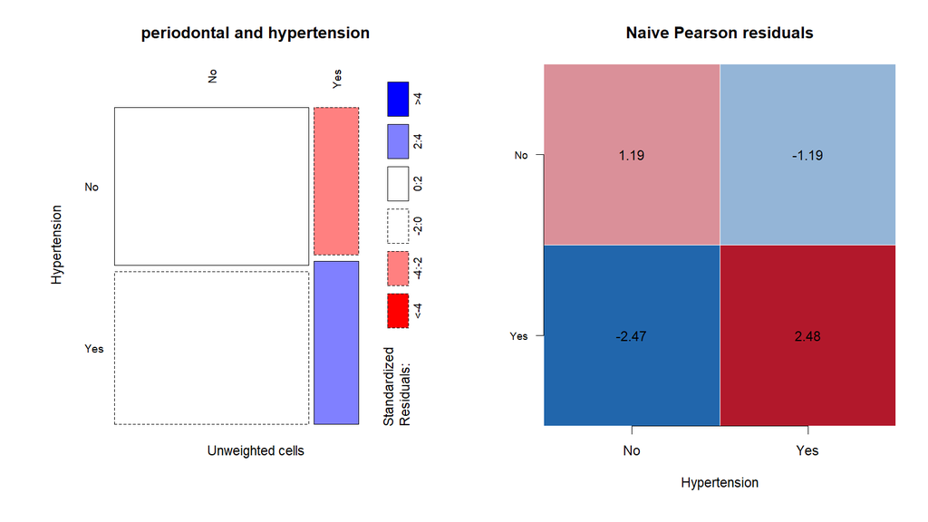

원본 PNG ↗

### 보정 모형은 표 각주별로 만들었다

Table2 Model1부터 나이·성별·인종·교육을 보정하므로 crude 모형이 아닙니다. Table2 M2에는 흡연이 추가되지 않지만, Table3 M2에는 흡연이 들어가며 CVD·당뇨·식이는 빠집니다. Table3 M1은 연령군별 분석에서 나이를 넣지 않습니다. 보충표 M2도 별도 공변량 구성을 사용합니다.

OR·CI는 설계 기반 로지스틱 모형으로 계산하고 주 결과는 잔차 자유도의 t 추론을 사용했습니다. 별도 z 민감도 값과 혼합하지 않습니다. 선정·모형·대비를 먼저 확인한 뒤 OR를 해석합니다.

각주별 모형과 비교 ↗모형·표본·수식 기록 ↗

04

REVISION & FRESHNESS

## 수정이 생기면 어떤 결과를 다시 계산했나

계획 수정, 실행 실패 수정, 결과를 본 뒤의 측정 정의 수정을 구분합니다. 이전 결과는 새 결과로 덮어쓰지 않았습니다.

1. 실행 전 / plan 1.1

### 연령 기준을 20세 초안에서 30세 이상으로 바로잡았다

   계획 검토 단계에서 수정했습니다. 잘못된 20세 기준의 실행 결과를 나중에 사전 계획처럼 숨긴 것이 아닙니다. 해당 초안으로 나온 수치는 없습니다.
2. 실행 전 / plan 1.3 → 1.4

### 주기별 음주·수면 문항과 보충표 모형을 대조했다

   ALQ_J 빈도 코드와 SLD012의 0.5시간 값을 반영했습니다. 유효 보충 PDF를 확보한 뒤 본문과 다른 공변량·분모를 별도로 구현했습니다. 보충표 선정은 공개된 counts를 근거로 추론했으며 저자 코드 확인은 아닙니다.
3. R1 실패 → R2 성공

### XPT 헤더 읽기 오류를 수정하고 새 실행을 만들었다

   초기 SAS XPT 헤더의 NUL 문자열 변환에서 실패했습니다. 앞 80바이트 ASCII 헤더를 확인하도록 수정하고 R2에서 실행했습니다. 이것은 자료 선정 정의의 수정과 다른 구현 오류입니다. R1 실패 기록은 남아 있습니다.
4. E1 실행·검토 후 / plan 1.5 → E2

### 2017–2018 검사법 차이 때문에 정의를 개정했다

   CDC BIOPRO_J 권고를 확인한 후 J 주기 creatinine·TG를 이전 주기 척도로 보정했습니다. E1을 읽은 뒤 이루어진 후속 수정이므로 전체를 사전등록 분석이라고 표현하지 않습니다. 공식 측정 근거에 따른 수정이며 저자의 실제 적용 여부는 미확인입니다.

   Creatinine(J) = 1.051 × raw − 0.06945  
   TG(J) = 0.9655 × raw − 7.020

   원값을 보존하고 결측 대체 전에 적용했습니다. [CDC BIOPRO_J 검사법 설명](https://wwwn.cdc.gov/Nchs/Data/Nhanes/Public/2017/DataFiles/BIOPRO_J.htm)

계획·실행 결정 기록 ↗계획1.5·코드 검토 ↗영향 범위와 재사용 계약 ↗

### 그대로 재사용한 것

**60개 M1/M2 모형 기록**과 변경 없는 기술표를 E1 출처·해시와 연결해 재사용했습니다. 표본 선정·결측 표시·영향 없는 원변수의 동일성을 확인했습니다.

### 새로 계산한 것

**36개 M3·추세·상호작용 모형**, 관련 검사값 Table 1 행, forest plot을 E2에서 갱신했습니다. E1은 보정 전 진단 기록으로 남으며 세 번째 후보가 아닙니다.

**실행 성공 ≠ 검토 승인 ≠ 원문 수치 일치**

독립 감사에서 R2 수치 56개, E1 수치 733개, E2 수치 371개, V1 검산 81개를 통과했습니다. E2 자료 검토는 380개 점검을 통과했습니다. 이 개수는 서로 다른 범위의 점검 수이며 모형 수·독립 표본 수가 아닙니다.

재사용·재계산 관계 ↗E2 수치 감사 ↗E2 자료 감사 ↗

### 현재 A 후보: Model 1–3 forest

E2-20261004

E2의 CDC 검사법 보정 정의를 사용한 현재 A(MEC) 후보입니다. M1/M2는 출처를 확인해 재사용했고 M3는 재적합했습니다. 모형 간 OR 변화는 교란 제거 효과만을 뜻하지 않습니다.

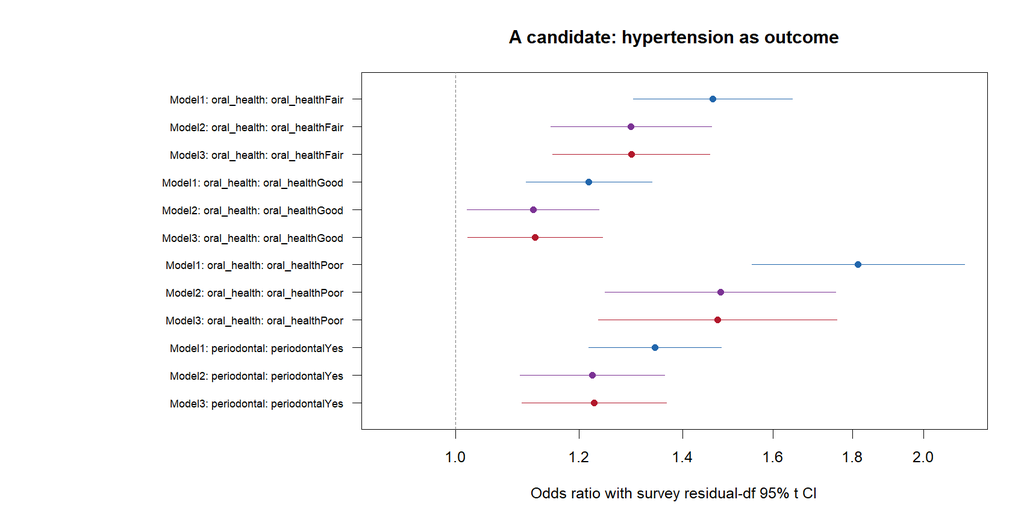

원본 PNG ↗

### B 민감도: 식이 가중 표본의 forest

E2-20261004

19,925명의 식이 가중 민감도 분석입니다. A보다 p가 작거나 출판값에 가깝다는 이유로 더 좋은 모형이라고 판정하지 않습니다. 표본·가중치 차이를 함께 읽습니다.

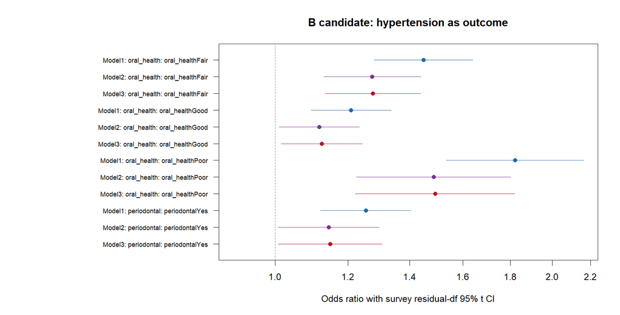

원본 PNG ↗

05

ASSIGNMENT EXTENSION

## 과제의 통계 원리는 어떻게 확인했나

V1은 실제 NHANES 복합표본 생성의 재현이 아니라, 정의한 교육용 표집·효과척도·짝지음 예제의 검증입니다.

### Fisher: 정확 열거 + Monte Carlo

집단당 n=5·10·20·50, 귀무 공통 p=0.05·0.2·0.5에서 가능한 표를 열거했습니다. R의 양측 probability-ordering Fisher p<0.05 규칙을 사용하고 조건당 10,000회, seed 20261004로 확인했습니다. 정보 없는 표는 비기각으로 정했습니다.

예: n=5, p=0.5에서 실제 기각확률은 **2.1484%**입니다. 명목 5%보다 낮습니다. n=10/10·전체 성공 10으로 주변합을 고정한 조건부 기각확률은 **2.3014%**입니다. 서로 다른 조건을 섞지 않습니다.

### OR와 PR: 같은 crude 표를 비교

출판 비가중 치주질환 표에서 노출군 고혈압 유병률은 53.34%, 비노출군은 49.89%입니다. crude OR=1.14835, PR=1.06922로 두 배수의 상대 차이는 약 **7.40%**입니다.

횡단면 결과이므로 PR은 유병률비입니다. “발생 위험이 7.4% 증가”라는 뜻도, adjusted OR를 RR로 바꾼 결과도 아닙니다.

과제 검증 전체 설명 ↗오류율·MC 불확실성 ↗crude OR·PR 계산 ↗

### Fisher의 실제 기각확률

V1-20261004

선·점은 특정 귀무 p에서의 정확 열거 기각확률, 오차막대는 10,000회 MC의 Wilson 95% CI입니다. 명목 5% 점선과 비교합니다. 전체 귀무공간에서 최대 size를 구한 그림은 아닙니다.

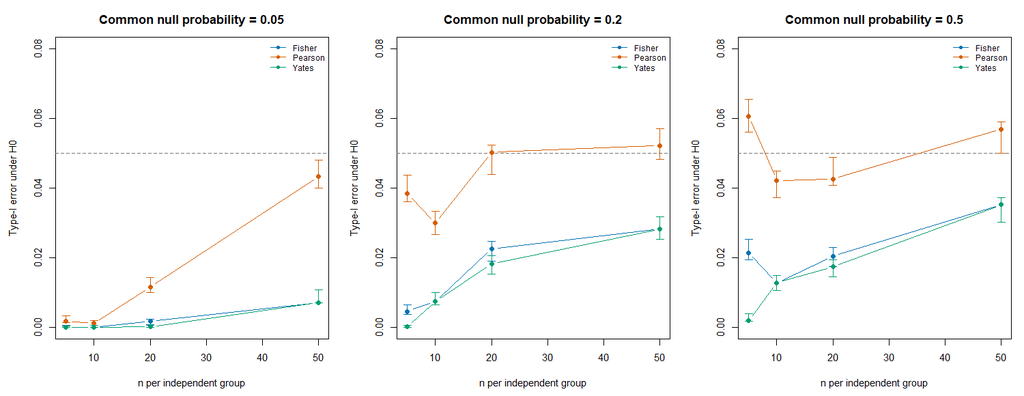

원본 PNG ↗

### 기저유병률이 높을 때 OR와 PR의 차이

V1-20261004

PR을 고정한 crude 표에서 p₀가 커지면 OR가 1에서 더 멀어지는 관계입니다. p₁<1인 정의역만 표시하며, 점은 출판 비가중 표를 나타냅니다. 보정 OR의 변환은 하지 않았습니다.

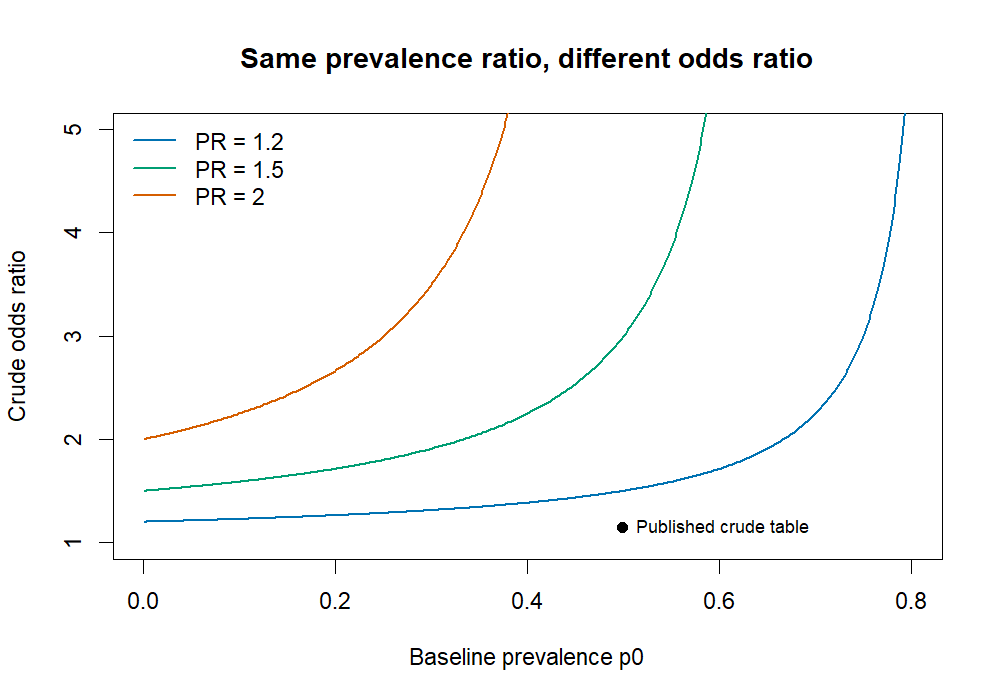

원본 PNG ↗

### McNemar: 실제 자료 적용과 강의 예제를 구분

이 NHANES 분석에는 같은 사람의 전후 짝지음 구조가 없으므로 McNemar의 실자료 적용은 해당 없습니다. 가상 100명 표 (40, 25; 5, 30)의 불일치 쌍 25 대 5에서 정확 이항 p≈0.000324914를 검산했습니다. 이 값은 논문 고혈압 연관의 p값이 아닙니다.

강의 가상 예제 ↗V1 독립 검산 ↗

**나머지 그림 5개와 해석 범위 보기**

### 검정력: 고정 대립가설의 표본수 변화

V1-20261004

p₀=0.20, p₁=0.35에서 정확 열거 검정력의 선·점입니다. MC·Wilson CI는 별도 CSV에 있습니다. 이 그림으로 논문 표본의 사후 검정력을 계산하지 않았습니다.

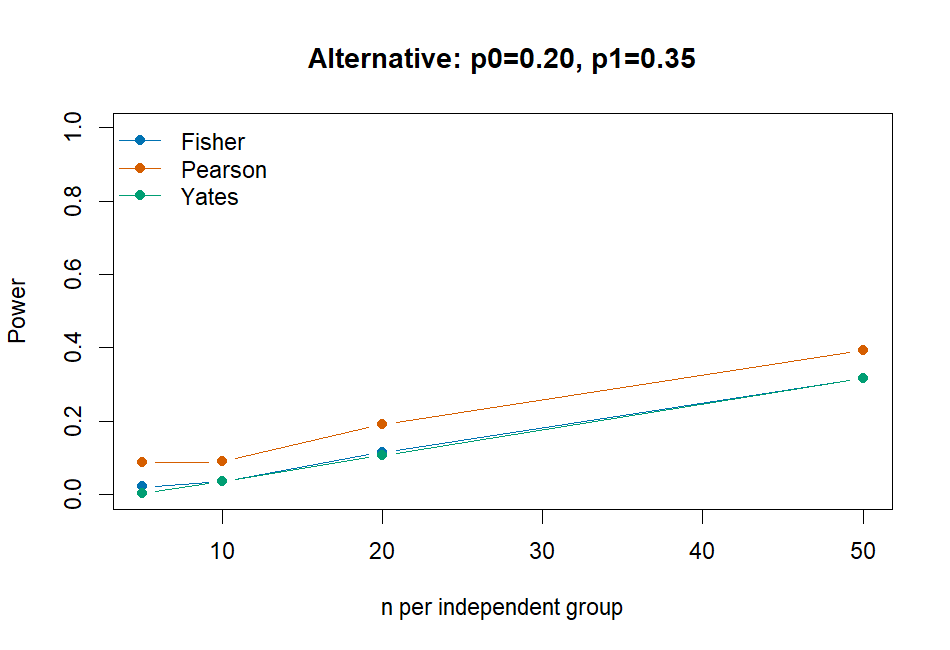

원본 PNG ↗

### 구강상태 4범주 × 고혈압

R2-20261004

같은 기본 표본의 비가중 모자이크·Pearson 잔차입니다. 모집단 추론은 별도 설계 기반 검정을 읽습니다.

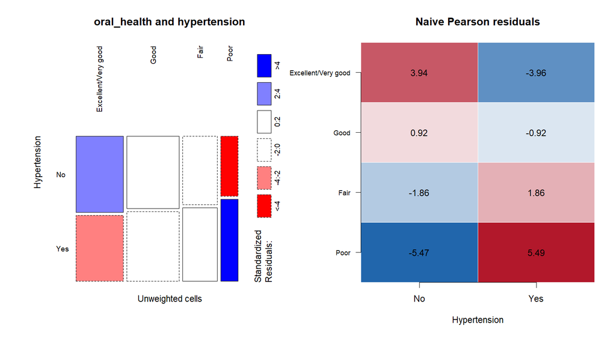

원본 PNG ↗

### 평생흡연 후보 × 고혈압

R2-20261004

SMQ020 후보의 비가중 탐색 그림입니다. 저자가 현재흡연을 사용했는지 확정한 그림은 아닙니다.

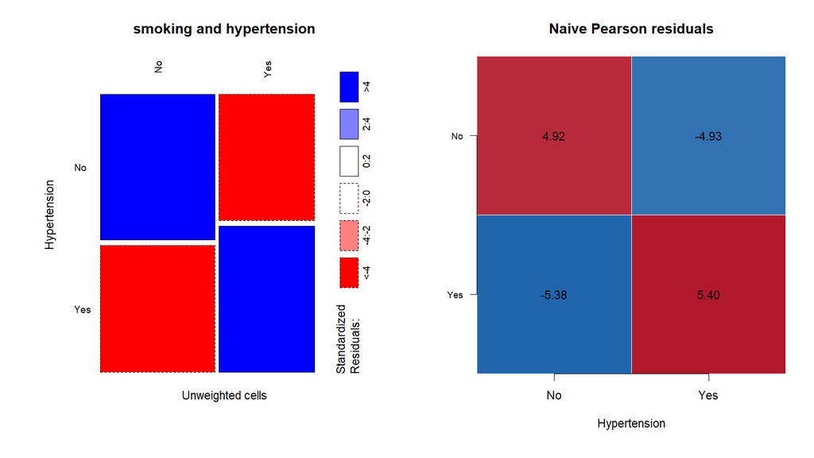

원본 PNG ↗

### 기본 분석 R2의 Model 1

R2-20261004

초기 기본 분석의 보정 Model 1을 보존한 그림입니다. Model 1은 crude가 아니며 E2의 M1/M2 재사용 출처와 구별해 읽습니다.

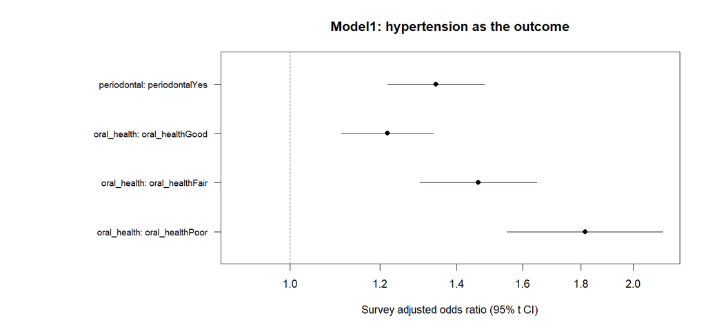

원본 PNG ↗

### J 주기 검사값 보정 점검

E2-20261004

CDC의 이전 주기 척도 변환을 적용한 값의 점검입니다. 보정 자체가 저자의 설정을 복원하거나 결측·측정 편향을 해결했다는 증거는 아닙니다.

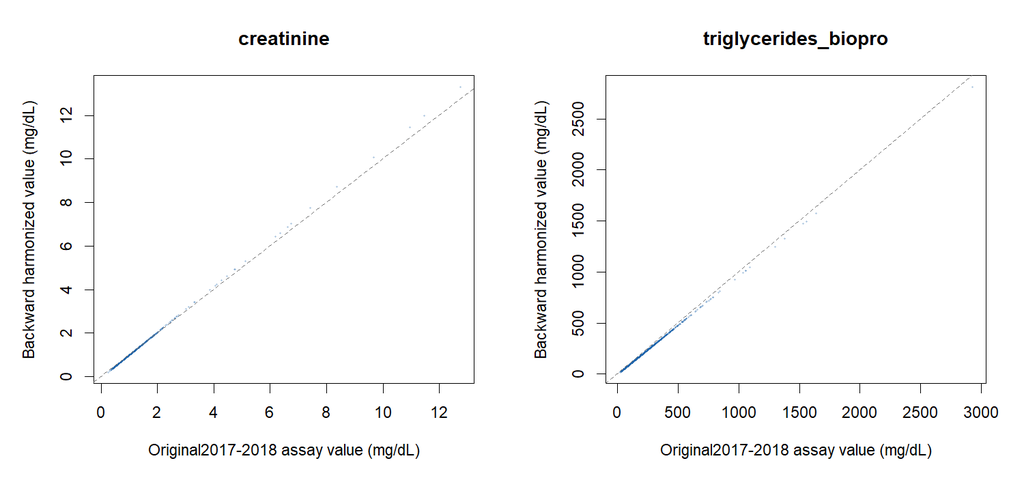

원본 PNG ↗

06

ISSUE REGISTER

## 처음 남긴 의문은 어디까지 해결됐나

아래 상태는 작업의 accept와 다른 과학적 해결 상태입니다. “부분 해결”은 실행 가능한 후보와 근거는 생겼지만 저자 설정까지 확인하지 못했다는 뜻입니다.

**ISSUE-01과제의 “구강검진”과 논문의 측정이 같은가?해결**

**수행** · 원문은 자가보고 OHQ835·OHQ845이다. 임상 치주검진을 재현했다고 부르지 않는다.

**남는 범위** · 측정 방식은 확인했지만 자가보고의 측정오류는 남는다.

해당 단계 01-paper ↗

**ISSUE-02혈압 평균과 약물 문항의 skip을 어떻게 처리하는가?부분 해결**

**수행** · 유효한 모든 1~4회 SBP/DBP를 평균하고, 진단·치료·측정의 양성 근거를 합쳤다. 구조적 약물 skip은 분기 근거로 구분했다.

**남는 범위** · 공식 응답 의미를 확인한 분석자 후보다. 저자의 정확한 평균·분기 코드와 같다는 증거는 없다.

해당 단계 02-paper ↗

**ISSUE-03흡연 Yes/No는 평생흡연인가 현재흡연인가?부분 해결**

**수행** · 기본 후보는 SMQ020의 평생 100개비 이상 여부를 사용했고 코드 의미는 확인했다.

**남는 범위** · 저자의 실제 흡연 정의가 미공개이므로 현재흡연과 같은 뜻으로 읽지 않는다.

해당 단계 02-paper ↗

**ISSUE-04논문 N=21,800을 정확히 만들 수 있는가?미해결**

**수행** · 선정 흐름을 계산했지만 최종 21,458명으로 342명 적다.

**남는 범위** · 누가 어떤 규칙으로 제외됐는지 저자의 코드 없이 확정할 수 없다.

해당 단계 03-paper ↗

**ISSUE-05식이·TG 자료에 어느 가중치를 써야 하는가?부분 해결**

**수행** · A=MEC/5, B=day1 식이 가중치/5로 구분했다. TG는 BIOPRO LBXSTR 비공복 후보다.

**남는 범위** · B는 표본과 가중치가 함께 바뀐다. 저자의 TG 변수·공복 제한·가중치 선택과 같은지 미확인이다.

해당 단계 03-paper ↗

**ISSUE-06일반 Fisher와 survey 검정은 같은 질문에 답하는가?해결 범위 명시**

**수행** · 비가중 Pearson/Yates/Fisher는 교육 비교, Rao–Scott는 설계 기반 추론으로 구분했다.

**남는 범위** · 작은 p를 이유로 우월한 검정을 고르지 않는다. 원문의 survey χ² 구현 상세는 미확인이다.

해당 단계 04-paper ↗

**ISSUE-07공변량·결측 처리·모형 설정을 복원할 수 있는가?부분 해결**

**수행** · 본문 Table2·Table3와 보충표 각주를 각각 적용했다. 범주 Missing, 연속 중앙값+지시변수는 분석자 후보다.

**남는 범위** · 저자의 대체값·흡연·당뇨 매핑 등 미공개 설정은 확정하지 못했다.

해당 단계 05-paper ↗

**ISSUE-08보정 OR는 인과효과이고 모형 간 변화는 교란 제거인가?한계 유지**

**수행** · 횡단면 연관, 자가보고, 잔여교란·역인과·선정 편향과 OR 비축약성을 고려했다.

**남는 범위** · 인과효과를 식별하거나 편향이 제거됐음을 입증한 분석이 아니다.

해당 단계 05-paper ↗

**ISSUE-09Fisher의 명목 5%가 실제 기각확률과 같은가?조건 내 해결**

**수행** · 독립 이항 시나리오를 정확 열거하고 조건당 10,000회 MC로 검산했다.

**남는 범위** · 정한 귀무 p·집단당 n의 결과다. 모든 귀무공간의 최대 size나 NHANES 표집 모의실험은 아니다.

해당 단계 06-paper ↗

**ISSUE-10흔한 결과에서 OR를 RR처럼 읽으면 얼마나 다른가?조건 내 해결**

**수행** · 출판 비가중 분할표의 crude OR=1.14835와 PR=1.06922를 비교했다.

**남는 범위** · 두 배수의 상대 차이는 약 7.40%다. 발생 위험 증가율이나 보정 OR→RR 변환으로 읽지 않는다.

해당 단계 06-paper ↗

**ISSUE-11이 NHANES 자료에 McNemar를 적용할 수 있는가?실자료 해당 없음**

**수행** · 짝지은 전후 자료가 없어 실제 분석에 적용하지 않았다. 강의의 가상 100명 표로만 검증했다.

**남는 범위** · 가상 paired 예제 결과를 NHANES 연구의 증거로 연결하지 않는다.

해당 단계 06-paper ↗

**ISSUE-12상류 정의가 바뀌면 표·모형·그림·노트도 같이 바뀌는가?검토 범위 내 해결**

**수행** · E2에서 관련 M3·추세·상호작용·검사값 기술표·forest를 갱신하고 재사용 출처를 기록했다.

**남는 범위** · 해시는 같은 파일이라는 확인이다. 모든 과학적 가정의 타당성이나 외부 일반화를 보장하지 않는다.

해당 단계 07-paper ↗

### 실행과 검토 중 추가로 드러난 문제

| 문제 | 발견·대응 | 남는 한계 |
| --- | --- | --- |
| 원문 Table 1 성별 합계 | 고혈압 남성 5,412 + 여성 5,606 = 11,018명. 보고 총계 11,017명과 1명 차이를 기록했다. | 산술 불일치는 확인했지만 어느 셀이 맞는지 임의로 고치지 않았다. |
| 당뇨 문항·Missing 매핑 | 출판 No·Missing 분포가 DIQ010 후보와 크게 달랐다. 원문과 코드북을 대조했다. | 저자의 실제 문항·분기·결측 매핑은 미확인이다. 숫자 일치를 위해 응답을 변경하지 않았다. |
| HbA1c 단위 표기 | 후보 LBXGH는 %이며 원문의 mg/dl 표기와 구별했다. | 표기 문제와 저자 분석값의 단위를 같은 오류로 단정하지 않는다. |
| 보충표 분모 | 출판 counts를 근거로 측정고혈압과 진단/치료고혈압 domain 후보를 분리했다. 기본 HTN 중 진단·복약 상태 미확인인 측정 고혈압 11명은 두 보충 domain에서 빠진다. | 저자 코드로 검증한 선정은 아니다. 기본 HTN 전체와 보충 두 집단의 합을 무조건 같게 만들지 않는다. |
| 모형의 상수·선형 종속 열 | 전체 96개 모형 중 54개에서 총 96개 열의 생략을 sidecar로 확인했다. B의 Na·fat 결측지시변수는 관측 식이 조건으로 상수가 된다. | 수식에 변수가 적혀 있다고 모든 계수가 추정된 것은 아니다. lean 기록의 aliased=[]만으로 생략이 없었다고 판단하지 않는다. |
| 경고 기록의 범위 | E2의 새 경고 0은 E1에서 재사용한 출력의 경고를 지우지 않는다. R 시작의 LC 경고와 V1의 미수집 warnings=[]도 구분했다. | 빈 배열을 “경고가 전혀 없었다”는 증거로 쓰지 않는다. |
| 수면·음주 문항의 주기 차이 | 수면 반시간 소수값을 보존하고 ALQ_J 빈도 코드를 수정했다. 음주 구간 대표빈도와 평생 12잔 미만 비음주 proxy를 사용했다. | 주기별 질문이 완전히 같지는 않다. 음주 대표값·proxy는 분석자 근사 가정이다. |
| 검사법 보정의 추가 불확실성 | CDC 교량 회귀 계수를 고정값으로 사용해 이전 척도로 변환했다. | 교량 계수 추정의 불확실성을 회귀 CI에 전파하지 않았다. 보정 후 측정오차가 없다고 판단하지 않는다. |
| 복약 특별코드의 skip 위험 | raw 7/9의 구조적 No 변환은 현재 자료에서 0명으로 확인했다. | 현재 결과에 영향이 없다는 점검이며, 다른 자료에서 같은 분기 규칙의 안전성을 보장하지 않는다. |
| 공통 완전사례 민감도 | 선택 옵션으로 남겼고 현재 실행 결과는 없다. | 완전사례 결과로 결측 편향을 검증했다고 설명할 수 없다. |
| 운영 메타데이터 | 이동 후 root와 이미지 경로는 갱신됐지만 과거 검토·등록부의 절대경로 일부는 이전 위치를 보존한다. HTML은 현재 상대경로로 연결한다. | stage_registry의 실행·검토 목록은 단계별 세밀한 검증 범위를 대신하지 않는다. 실제 노트·coverage·review를 함께 확인한다. |

원문·코드북 문제 근거 ↗생략 열 목록 ↗수치·경고·재사용 범위 ↗등록부 메타데이터 ↗

07

INTERPRETATION

## 계산이 맞아도 결론은 어디까지인가

최종 판정은 세 가지를 나누어 읽습니다: 계산 확인, 저자 설정 확인, 과학적 해석 범위.

| 판정 축 | 현재 상태 | 판정의 의미 |
| --- | --- | --- |
| 계산·파일 일관성 | 범위별 독립 검토 accept | 검토한 자료·수치·모형 재적합·문서 연결의 점검을 통과했다. |
| 저자 구현의 확인 | 일부 확인 / 일부 식별 불가 | 측정·각주 일부는 확인했지만 선정·결측·흡연·TG·가중치 등 숨은 선택이 남는다. |
| 논문 수치의 재현 | 부분 재현 | N이 다르고 84개 OR 비교 중 원시 OR 값 기준 0.005 내 일치는 7개다. CI·n 일치까지 뜻하지 않는다. |
| 인과·외부 일반화 | 이번 작업으로 입증하지 않음 | 자가보고 횡단면 연관 분석이며 새 독립 표본 검증이나 인과효과 식별을 수행한 것이 아니다. |

**확정하지 않은 것**

“치주질환 치료가 고혈압을 예방한다”, “보정 후 교란·선정·결측 편향이 제거됐다”, “OR가 곧 RR이다”, “Fisher 결과가 모든 표집에서 같다”, “출판값에 가까운 모형이 더 타당하다”는 결론을 내리지 않습니다.

### 남은 의문을 풀려면 어떤 증거가 더 필요한가

1. **저자 분석 코드·변수 목록·제외 흐름** — 혈압 평균, 약물 skip, 흡연·당뇨 문항, 결측 대체와 가중치의 정확한 설정을 확인해야 한다.
2. **TG와 검사법 처리 내역** — BIOPRO/공복 reference 변수, 공복 제한, J 검사법 변환 여부를 확인해야 한다.
3. **가정이 바뀌는 별도 분석 계획** — 결측·선정·측정 가정의 추가 민감도는 추정 대상과 평가 기준을 고정하고 새 run으로 수행해야 한다. 작은 p나 출판값 근접을 목적함수로 쓰지 않는다.
4. **다른 자료·설계의 증거** — 외부 일반화나 인과 주장은 현재 자료의 수치 감사만으로 해결되지 않는다.

위 항목은 남은 질문과 필요한 증거이며, 이미 실행한 추가 분석으로 표시하지 않습니다.

84개 OR·CI·n 비교 ↗최종 해석·재현 한계 ↗문서 해석 검토 ↗

08

READ THE RECORD

## 설명을 확인하고 다시 따라갈 파일

HTML의 수치·그림은 아래의 저장된 실행을 바탕으로 만들었습니다. 이미지를 HTML 안에 포함해 별도 서버 없이도 읽을 수 있습니다.

### 프롬프트·계획

- 전체 실행 프롬프트 원본 ↗
- 5주차 적용 규칙 ↗
- E2 최종 계획 ↗
- 계획 개정의 사유 ↗

### 실제 분석·검증

- 기본 분석 코드 ↗
- 확장 모형 코드 ↗
- 검사법 보정 코드 ↗
- 과제 검증 코드 ↗

### 결과·비교

- R2 기본 결과 ↗
- E2 현재 결과 ↗
- V1 검증 결과 ↗
- 비교·출처 해시 ↗

### 검토·학습 문서

- 학습 문서 시작 ↗
- E2 독립 수치 검토 ↗
- 최종 문서 검토 ↗
- 재실행 안내 ↗

GitHub 공유본에는 원자료 XPT·개인별 파생 CSV·RDS·설치 패키지·캐시가 없습니다. 다운로드·재생성은 실행 안내를 따릅니다. 과거 실행·검토 해시는 당시 전체 로컬 산출물 기준이며, 실제 공유 파일 해시는 publication_manifest.json에서 확인합니다. GitHub의 파일 화면은 HTML 원문을 보여 주므로 다운로드해서 브라우저로 열면 이 자료를 읽을 수 있습니다.